# Music order

### Preliminary results

```r
dt = fread("novo.csv")

dt %>% select(album_id, track_number, valence,
              energy, loudness, tempo) %>%
       head()
```

A data.table: 6 × 6

| album_id <chr> | track_number <int> | valence <dbl> | energy <dbl> | loudness <dbl> | tempo <dbl> |
| --- | --- | --- | --- | --- | --- |
| 008M3KxE8IO39sdTRFeZwn | 1 | 0.575 | 0.892 | -4.734 | 110.031 |
| 008M3KxE8IO39sdTRFeZwn | 2 | 0.944 | 0.844 | -5.478 | 95.001 |
| 008M3KxE8IO39sdTRFeZwn | 3 | 0.725 | 0.723 | -4.468 | 89.940 |
| 008M3KxE8IO39sdTRFeZwn | 4 | 0.608 | 0.723 | -5.651 | 107.012 |
| 008M3KxE8IO39sdTRFeZwn | 5 | 0.728 | 0.859 | -5.399 | 119.976 |
| 008M3KxE8IO39sdTRFeZwn | 6 | 0.813 | 0.865 | -4.767 | 97.948 |

# Feature distribution

Chunk album positions; Get descriptives by album; Get overall descriptives

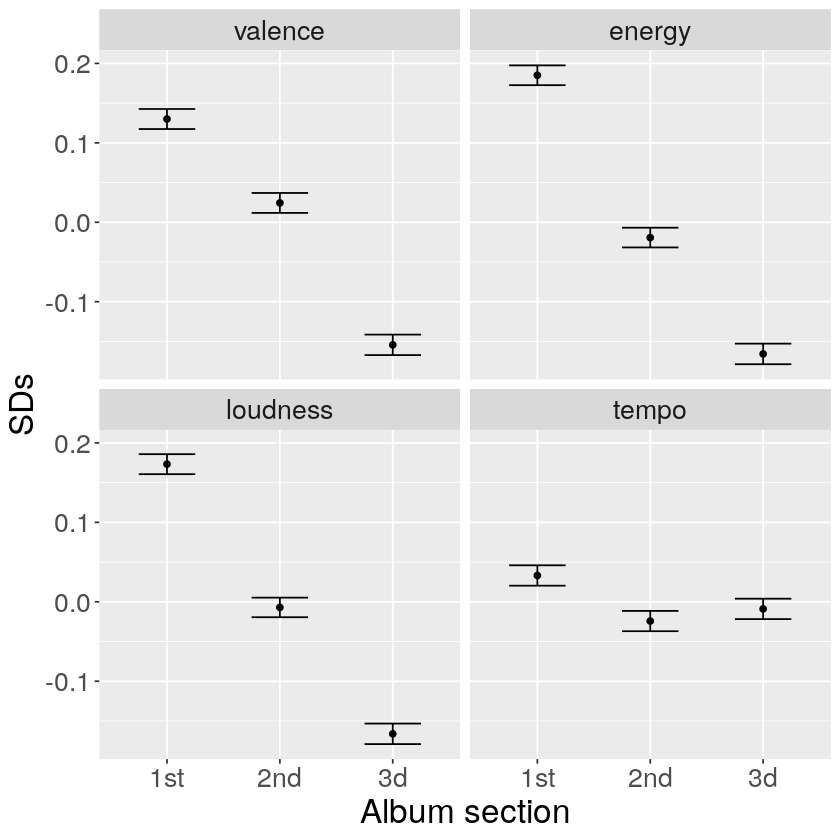

```r
dt %>% ggplot(aes(x = posicao_track, y = value)) +
            facet_wrap(~variable)+ xlim("1st","2nd", "3d")+ geom_point()+
            geom_errorbar(aes(ymin=value-se, ymax=value+se), width = .5) +
            theme(text = element_text(size = 20)) + xlab("Album section") + ylab("SDs")
```

# Dissimilarity matrix

Dissimilarities were computed between all pairwise combinations of tracks $(A, B)$ within the same album, and summed across all features $f$. Then the dissimilarities were averaged across all albums $k$:

\begin{equation}\label{eq:um} d(A, B) = \frac{1}{k}\sum\limits_{1}^{k}\sqrt{\sum \limits_{1}^{f} (A_{kf}-B_{kf})^2 } \end{equation}

The output of $d(A, B)$ constitutes the mean dissimilarity dissimilarity between two tracks in positions $A$ and $B$.

# Results

Dissimilarity matrix calculated from original dataset

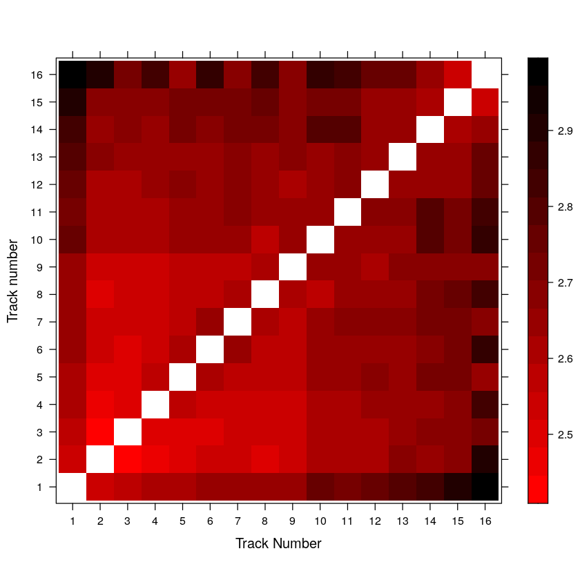

```r
levelplot(dt, col.regions = redblack, xlab = "Track Number", ylab = "Track number")
```

# Results

Dissimilarity matrix calculated from shuffled dataset. Each album was shuffled within itself and dissimilarity metrics were calculated again.

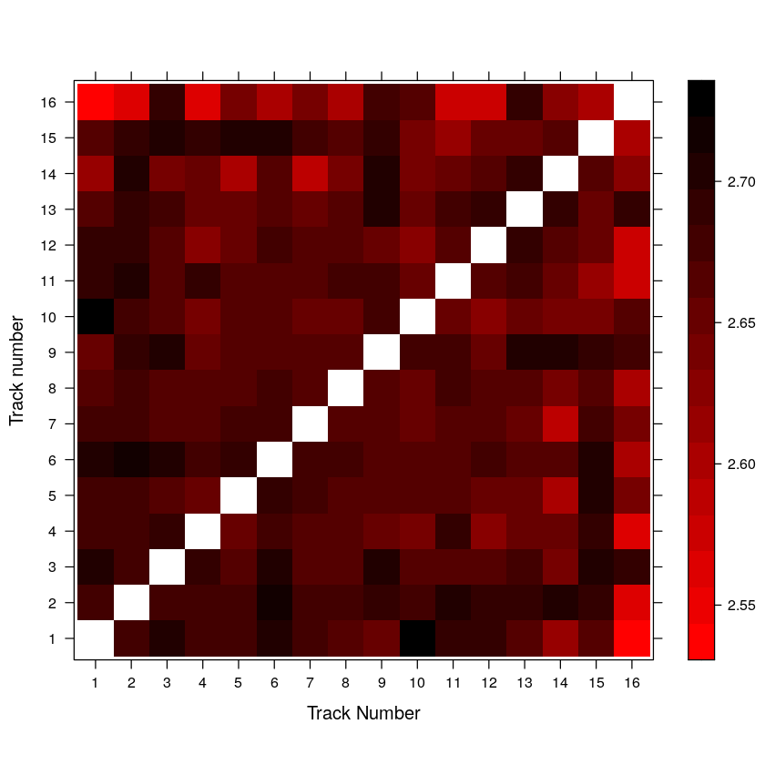

```r
levelplot(r, col.regions = redblack, xlab = "Track Number", ylab = "Track number")
```

# Dissimilarity by album segment

Next we collapsed each album in 4 different segments (see segmentation strategy below). Then we computed the average feature for each album section. Dissimilarity measurements were taken again using Eq. 1, but with the tuple $(A, B)$ meaning all pairwise combinations of album sections, instead of album tracks.

## About the segmentation strategy

Since albums were segmented in 4 parts, the number of tracks within each each section is equal to the nearest integer to $\frac{length\ of\ album}{4}$.

The size of the last section is determined according to the following:

- If we round up, last chunk is smaller;
- If we round down, last chunk larger;
- If $\frac{length\ of\ album}{4} = x.5$, section length is rounded up 1 out of 3 times.

# Results

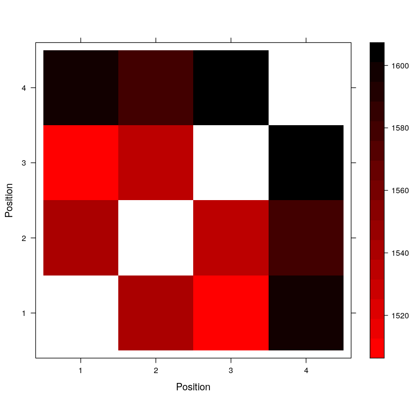

```r
#Dissimilarity by section
dt %>% levelplot(xlab = "Position", ylab = "Position",
                 col.regions=redblack)
```

## Section lengths

```r
dt = fread("novo.csv")
dt %<>% select(!V1)
dt %>%
    group_by(album_id) %>% mutate(album_length = NROW(track_number)) %>%
    filter(album_length < 17) %>% filter(album_length > 5) %>%
    mutate(posicao_track = segment2(track_number)) %>%
    mutate(album_section = segment2(track_number)) %>% group_by(album_section)%>%
    summarise(n_tracks_per_section = NROW(album_section))
```

A tibble: 4 × 2

| album_section <chr> | n_tracks_per_section <int> |
| --- | --- |
| 1st | 11928 |
| 2nd | 11928 |
| 3d | 11928 |
| 4th | 12301 |

# Upsampling

Each album has a certain length, and as shown before, this might affect some of the descriptive statistics that we are computing.

In order to normalize the length of each album, we can duplicate the track of each album to $\frac{n}{Al}$ times, where $n$ is the Least Common Multiplier $LCM$ of all album lengths $Al$.

## Alternative

We can exclude some albums in order to minimize LCM, while also minimizing the loss of albums from our dataset. This was implemented and shown below.

# Procedure

```r
group <- c(); n_groups <- c(); lcm <- c(); size <- c()
for(i in 2:11){
    n_groups <- c(n_groups, i)
    mt   <- combn(unique(j$album_length), i) # every combination
    lcms <- apply(mt, 2, LCM) # get LCMs for each combination
    winner <- mt[, which(lcms == min(lcms))] # album sizes of lowest LCM
    group[[i-1]] <- paste("album ", winner) # group with lowest lcm
    lcm <- c(lcm, min(lcms)) # lcm of winner
    size <- c(size, nrow(filter(j, album_length %in% winner)))
}; tibble("LCMs" = lcm, "Size of dataset after cut" = size)
```

A tibble: 10 × 2

| LCMs <int> | Size of dataset after cut <int> |
| --- | --- |
| 12 | 8442 |
| 24 | 10538 |
| 48 | 15386 |
| 120 | 20943 |
| 240 | 25791 |
| 720 | 27627 |
| 1680 | 34800 |
| 5040 | 36636 |
| 55440 | 42422 |
| 720720 | 49065 |

1. 12

2. 24

3. 48

4. 120

5. 240

6. 720

7. 1680

8. 5040

9. 55440

10. 720720

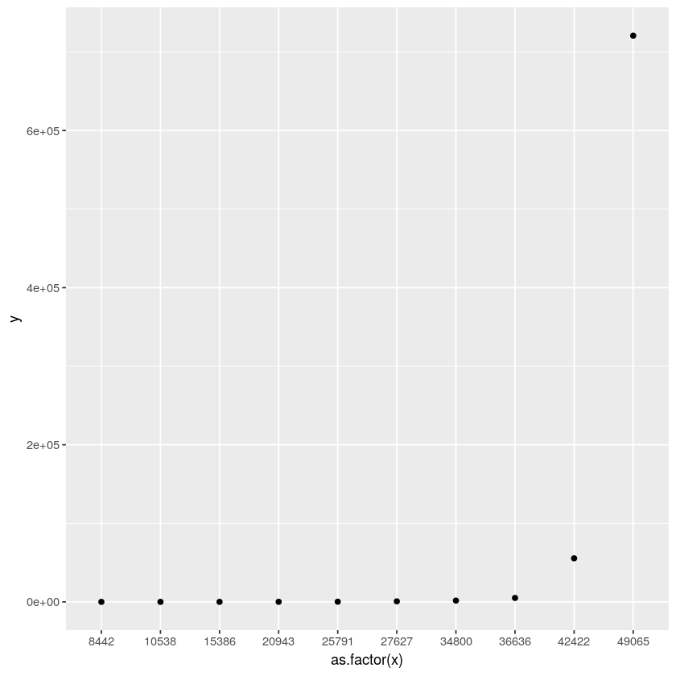

```r
data.frame(x = size, y = lcm) %>%
    ggplot(aes(x = as.factor(x), y = y), group = 1) +
    geom_point(); lcm
```

# Conclusion

If we keep albums of size 6, 7, 8, 9, 10, 12, 14, 15 and 16, we decrease LCM to 5040, and the number of tracks in our data to 36636. We loose around 12 thousand tracks, but our dataset decreases from 3 billion to 25 million datapoints.

Next I'm implementing the upsampling by the factor of 5040

# Remaking the heatmaps

[figure not shown]

```r
j %>%
    as.matrix() %>%
    levelplot(col.regions= redblack, xlab = "Track Number", ylab = "Track number")
```